# Ford_gobike-trip Data Exploration

## Investigation Overview

In this investigation, I'm most interested in analysing which features contributes most to the usage of the bikes. Identify patterns that associates with how the bikes are used in terms of period, member attributes and location.

## Dataset Overview

This data set includes information about individual rides made in a bike-sharing system covering the greater San Francisco Bay area. The data was recorded in February 2019 with 183412 records and 16 features. Some data points were removed from the analysis due to missing information and outliers.

The cleaned dataset contains 174952 trip record in the dataset with 10 features giving details( start_station_name, end_station_name, bike_id, user_type, member_gender, bike_share_for_all_trip, hour, day_period, age, duration).

## Distribution of Age

After dropping outliers in this data the age range between 20 and 100. Majority of the users are between age 25 and 40. The distribution is right skewed.

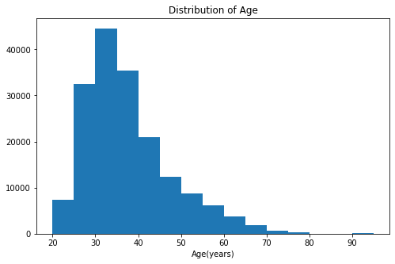

## Categories of Gender

There are 3 categories of the members gender; Male, Female and Others. The Male Gender dominate the membership, followed by the Female gender and lastly the Others. More than 70% of the Members are Male.

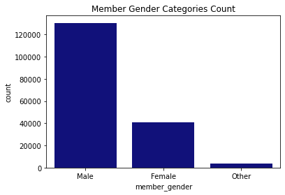

## User Type Categories

There are 2 categories of members; Customer and Subscriber. 90.5% of the Members are Subscribers and the 9.5% are Customers

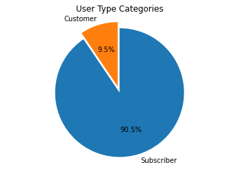

## Most Common Station

There are 329 unique Start and End stations in the dataset. Market St at 10th St, San Francisco Caltrain Station 2(Townsend St at 4th St), Berry St at 4th St, Montgomery St BART Station(Market St at 2nd St) are the most common Start and End Stations for the members trip within the city.

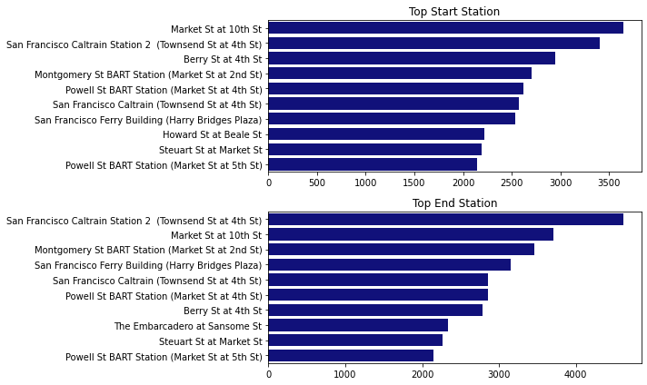

## Categories of Trip Period

Most trip are taken in the Morning, followed by Evening and less at Night.

Specifically, between 7AM and 9AM in the Morning, and between 4PM and 6PM in the Evening exist the highest trip. This period happen to be the resumption hour and closing hour respectively in the city which contribute to the increase in trip usage. Trips count between 10AM and 3PM, which fall within office hour, are relatively constant. The trip count then drop from 7PM till 6AM.

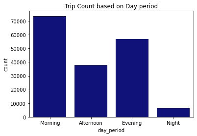

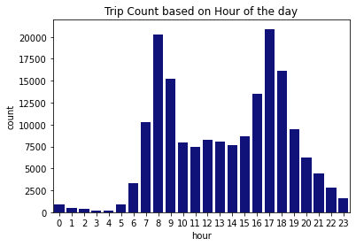

## Distribution of Trip Duration

Using the log scale the duration distribution becomes relatively a normal distribution. Majority of the trips are between 5 to 25mins, fairly a short trips. The average trip is 9mins. From the normal distribution it can be concluded that 90% of the trip duration is less than 30minutes

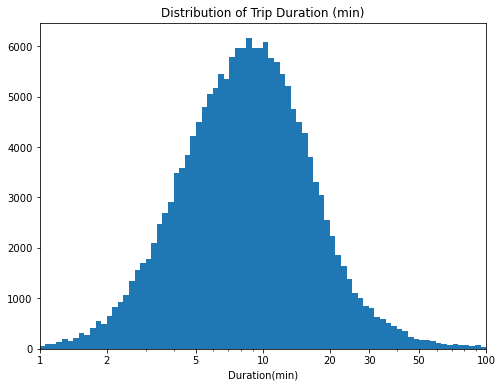

## Categories of Share Trip

Majority of the member do not share bike for trip. Only few, about 10%, prefer to share bikes for trip

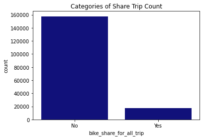

## Age vs. Hour/Duration

It is observed from that correlation between duration and age is close to 0, impling that there is no linear relationship between them. Age and hour shows a weak negative correlation.

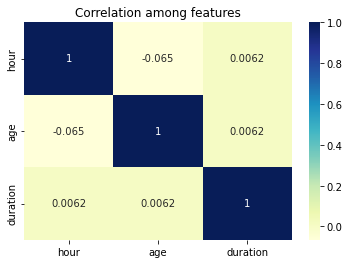

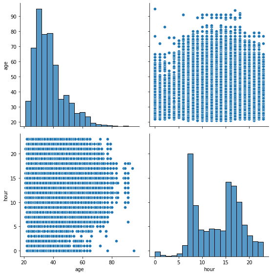

## Member Info vs. Trip Info

The average duration for subscriber is lower than that of customers and 75% of the subscriber duration is lower than the average duration for customers.

The female gender and other spend a little more time than the male which is quite expected. And the average age for the other gender is higher than the male and female with female having the lowest.

Customers that do not share bike for trips spend have higher duration and the average age is higher compared to those that share

The average age of customers that use the bike in the afternoon is high in the morning and low in the night. The evening and afternoon remained fairly the same.

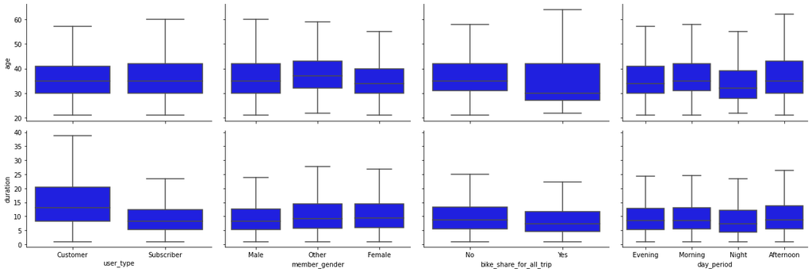

## Total Duration From Start or End Station

As expected, some of the top start duration are still topping in total duration covered for the period. Market St at 10th St, San Francisco Caltrain Station 2(Townsend St at 4th St), Berry St at 4th St, Montgomery St BART Station(Market St at 2nd St) are example.

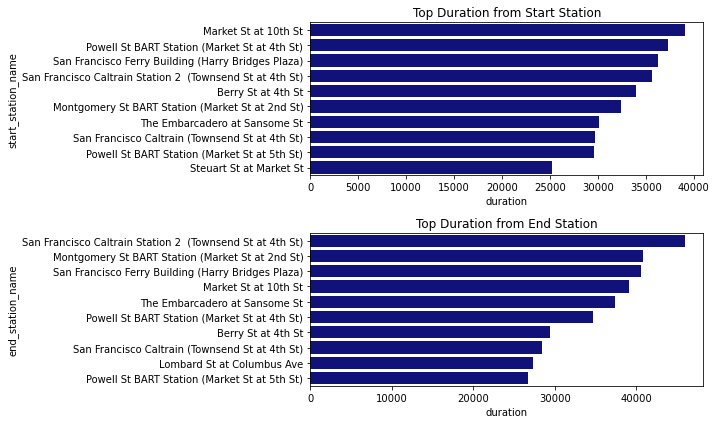

## Member Info and Day Period

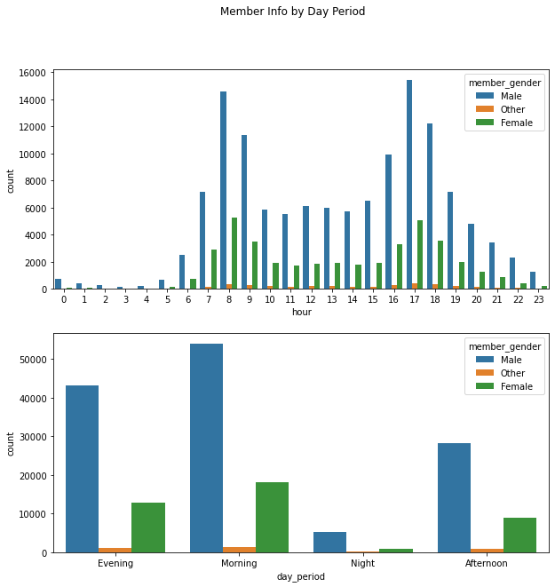

## Member Info vs. Duration

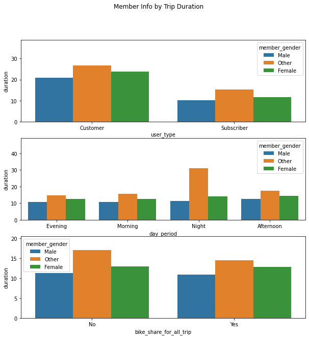